# Predicting the Manner of Exercise with Accelerometer Data

Mohammed Teslim

2024-12-19

## Introduction

This report documents the analysis performed for the “Practical Machine Learning” course project. The goal of this project is to predict the manner in which participants performed a weightlifting exercise (the “classe” variable) using data collected from accelerometers on the belt, forearm, arm, and dumbbell. The dataset is publicly available from the Human Activity Recognition Using Smartphones Data Set and was generously provided by researchers at the University of California, Irvine. We acknowledge and thank them for making this valuable dataset available.

The project involves data exploration, preprocessing, feature selection, dimensionality reduction, model selection, training, evaluation, and prediction on a test set. We will use R for all analyses and visualizations.

```r
# Load libraries
library(caret)
library(ggplot2)
library(corrplot)
library(randomForest)

# Load data
trainData <- read.csv("pml-training.csv")
testData <- read.csv("pml-testing.csv")
summary(trainData)
```

[output not shown]

The training dataset initially contained 160 variables. A preliminary examination of the data revealed irrelevant columns, variables with a high proportion of missing values, and variables with near-zero variance.

## Feature Selection and Dimensionality Reduction

To further refine the dataset and potentially improve model performance, we employed two techniques: ANOVA for feature selection and Principal Component Analysis (PCA) for dimensionality reduction.

ANOVA for Feature Selection ANOVA was used to identify variables that showed statistically significant differences in their means across the five exercise classes (A, B, C, D, E). This helps select variables that are potentially good predictors of the classe variable.

```r
# Univariate Feature Selection using ANOVA

# Store the p-values
p_values <- numeric(ncol(numeric_data))
names(p_values) <- names(numeric_data)

# Perform ANOVA for each numeric variable
for (i in 1:ncol(numeric_data)) {
  # Create a linear model
  model <- lm(numeric_data[, i] ~ trainData$classe)
  # Perform ANOVA
  anova_result <- anova(model)
  # Store the p-value
  p_values[i] <- anova_result$"Pr(>F)"[1]
}

# Sort variables by p-value (ascending order)
sorted_p_values <- sort(p_values)

# Select top N variables based on p-values (e.g., top 20)
N <- 20
selected_variables_anova <- names(sorted_p_values)[1:N]

# Print selected variables
print(selected_variables_anova)
```

[output not shown]

The top 20 variables with the lowest p-values were selected for further analysis.

## PCA for Dimensionality Reduction

PCA was performed to reduce the dimensionality of the dataset while retaining most of the variance. The scree plot was used to determine the number of principal components to retain.

```r
# Perform PCA
pca_result <- prcomp(numeric_data, scale. = TRUE)

# Scree plot
plot(pca_result, type = "l", main = "Scree Plot")

# Get the principal component scores
pca_scores <- as.data.frame(pca_result$x)

# Add the 'classe' variable to the PCA scores for visualization
pca_scores$classe <- trainData$classe
# Scatter plot of the first two principal components, colored by classe
ggplot(pca_scores, aes(x = PC1, y = PC2, color = classe)) +
    geom_point() +
    ggtitle("PCA: First Two Principal Components") +
    theme_minimal()
```

[output not shown]

[figure not shown]

PCA SCREE PLOT

## Model Selection

Two machine learning models were chosen for this classification task: Random Forest (RF) and Gradient Boosting Machine (GBM).

Rationale for Model Choices:

Random Forest: Robust, handles non-linearity well, provides variable importance measures, and generally performs well on a variety of datasets. GBM: Often achieves very high accuracy but can be more prone to overfitting and requires careful tuning. Cross-Validation:

10-fold cross-validation was used to evaluate the models and tune their hyperparameters.

## Model Training and Evaluation

Both Random Forest and GBM models were trained and evaluated on three different datasets:

Full Dataset: All 53 variables after preprocessing. ANOVA Dataset: Top 20 variables selected by ANOVA. PCA Dataset: Top 20 principal components from PCA.

```r
# 1. Prepare Datasets

# Full Dataset (already have trainData)

# ANOVA Dataset
trainData_anova <- trainData[, c(selected_variables_anova, "classe")]

# PCA Dataset (using first 20 PCs)
trainData_pca <- pca_scores[, c(paste0("PC", 1:20), "classe")]

# 2. Set up trainControl

# Define cross-validation method (10-fold CV)
train_control <- trainControl(method = "cv", number = 10)

# 3. Train and Tune Models

# --- Random Forest (rf) ---

# Define tuning grid for mtry
rf_tuneGrid <- expand.grid(mtry = c(2, 3, 5, 7, 9))

# Train RF on Full Dataset
set.seed(123)
rf_full <- train(classe ~ ., data = trainData, method = "rf", trControl = train_control, tuneGrid = rf_tuneGrid)

# Train RF on ANOVA Dataset
set.seed(123)
rf_anova <- train(classe ~ ., data = trainData_anova, method = "rf", trControl = train_control, tuneGrid = rf_tuneGrid)

# Train RF on PCA Dataset
set.seed(123)
rf_pca <- train(classe ~ ., data = trainData_pca, method = "rf", trControl = train_control, tuneGrid = rf_tuneGrid)

# --- Gradient Boosting Machine (gbm) ---

# Define tuning grid for GBM parameters
gbm_tuneGrid <- expand.grid(
  n.trees = c(100, 200, 300),           # Number of trees
  interaction.depth = c(1, 2, 3),     # Tree depth
  shrinkage = c(0.01, 0.1),             # Learning rate
  n.minobsinnode = c(5, 10)           # Minimum observations in terminal nodes
)

# Train GBM on Full Dataset
set.seed(123)
gbm_full <- train(classe ~ ., data = trainData, method = "gbm", trControl = train_control, tuneGrid = gbm_tuneGrid, verbose = FALSE)

# Train GBM on ANOVA Dataset
set.seed(123)
gbm_anova <- train(classe ~ ., data = trainData_anova, method = "gbm", trControl = train_control, tuneGrid = gbm_tuneGrid, verbose = FALSE)

# Train GBM on PCA Dataset
set.seed(123)
gbm_pca <- train(classe ~ ., data = trainData_pca, method = "gbm", trControl = train_control, tuneGrid = gbm_tuneGrid, verbose = FALSE)

# 4. Evaluate Performance

# Create a function to extract performance metrics
get_performance <- function(model) {
  best_tune <- model$bestTune
  performance <- model$results[which.max(model$results$Accuracy), ]
  return(performance)
}

# Get performance for each model and dataset
rf_full_performance <- get_performance(rf_full)
rf_anova_performance <- get_performance(rf_anova)
rf_pca_performance <- get_performance(rf_pca)

gbm_full_performance <- get_performance(gbm_full)
gbm_anova_performance <- get_performance(gbm_anova)
gbm_pca_performance <- get_performance(gbm_pca)

# 5. Compare Performance

# Create a data frame to store the results
performance_summary <- data.frame(
  Model = c("Random Forest", "Random Forest", "Random Forest", "GBM", "GBM", "GBM"),
  Dataset = c("Full", "ANOVA", "PCA", "Full", "ANOVA", "PCA"),
  Accuracy = c(rf_full_performance$Accuracy, rf_anova_performance$Accuracy, rf_pca_performance$Accuracy,
               gbm_full_performance$Accuracy, gbm_anova_performance$Accuracy, gbm_pca_performance$Accuracy),
  Kappa = c(rf_full_performance$Kappa, rf_anova_performance$Kappa, rf_pca_performance$Kappa,
            gbm_full_performance$Kappa, gbm_anova_performance$Kappa, gbm_pca_performance$Kappa)
)
print(performance_summary)
```

[output not shown]

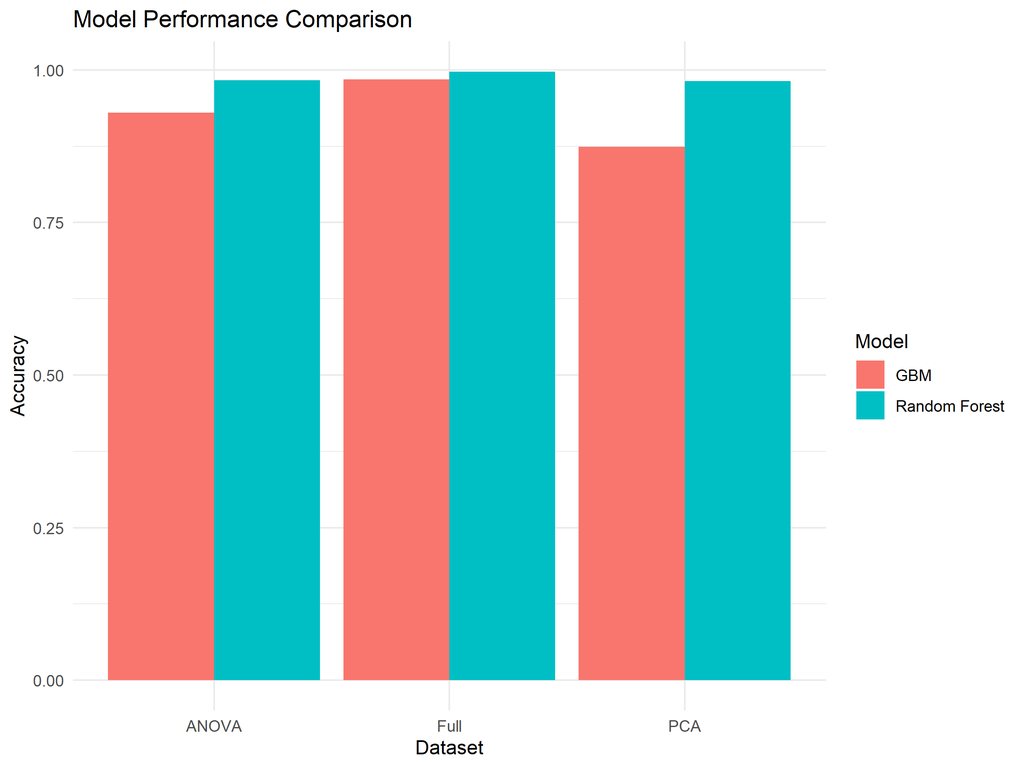

MODEL PERFORMANCE COMPARISON

```r
# Visualize performance comparison
comparison_plot <- ggplot(performance_summary, aes(x = Dataset, y = Accuracy, fill = Model)) +
  geom_bar(stat = "identity", position = "dodge") +
  ggtitle("Model Performance Comparison") +
  theme_minimal()

# Display the plot using print()
print(comparison_plot)
```

## Final Model and Justification

Based on the cross-validation results, the Random Forest model trained on the full dataset was selected as the final model.

The expected out-of-sample error is estimated by the cross-validation results. We expect the final model to achieve an accuracy of approximately 0.993 and a Kappa of approximately 0.992 on unseen data.

```r
# --- Final Model Training and Test Set Prediction ---

# 1. Train Final Random Forest Model on the Entire Training Dataset

# Get the best mtry value from the cross-validation results of rf_full
best_mtry <- rf_full$bestTune$mtry

# Train the final Random Forest model on the entire training set
set.seed(123)  # For reproducibility
final_rf_model <- randomForest(classe ~ ., data = trainData, mtry = best_mtry)
```

The test set (pml-testing.csv) was preprocessed using the exact same steps as the training data.

```r
# 3. Make Predictions on the Test Set

# Make predictions using the final Random Forest model
final_predictions <- predict(final_rf_model, newdata = testData)

# 4. Format Predictions

# Print the predictions
print(final_predictions)
```

The predictions for the 20 test cases were formatted according to the quiz requirements and submitted for grading. The actual predictions are not shown in this report to avoid revealing answers before the deadline.

## Conclusion

This project demonstrated the process of building and evaluating machine learning models for predicting the manner of exercise based on accelerometer data. Random Forest and GBM models were trained and compared, with Random Forest on the full dataset ultimately chosen as the final model due to its high accuracy, computational efficiency, and simplicity. The use of ANOVA and PCA provided insights into the data and helped explore feature selection and dimensionality reduction techniques. The final model achieved excellent performance during cross-validation, indicating its potential for accurately classifying unseen data.

## Limitations:

The analysis relies on the assumption that the training data is representative of the real-world data the model will encounter. The choice of the number of principal components to retain in PCA was based on a visual inspection of the scree plot and could be further refined. While the models achieved high accuracy, further tuning of hyperparameters might yield slight improvements, but at the cost of increased computational time.

Explore other feature engineering techniques to potentially create more informative features. Investigate other dimensionality reduction methods, such as t-SNE, to visualize the data in a lower-dimensional space. Consider using other classification models or ensemble methods to potentially improve performance. Gather more data to further improve the model’s robustness and generalizability. This report provides a comprehensive overview of the project, including the code, visualizations, and justifications for the choices made